# Assessment2

**(2-4):** Run your implementation of the Hebb rule on `data_HL_simple.txt`, and inspect the weights $w$ after every step of the algorithm. Identify the correlational pattern that the algorithm discovers. Are there any positively or negatively correlated features in these data according to the pattern seen in $w$?

```python
import numpy as np
import matplotlib.pyplot as plt

# load data from the text file
data = np.loadtxt('data_HL_simple.txt', usecols=range(5))
print(data[1:5,:])

# we need a vector of 5 parameters
w = np.random.normal(0, 0.5, 5)

print("initial weights")
print(w)

# learning rate; don't change the learning rate epsilon when you are working on questions 2 and 3, unless you really know what you are doing. You may want to make the learning rate dependent on the epoch number to converge to a stable solution.
epsilon = 0.01

num_iterations = 6

update = 0
# we can do a fixed number of iterations because the simple Hebb rule won't converge
for i in range(num_iterations):
    for x in data:

        # TODO: add your code here; note that "epsilon"
        # is defined above and it should be used here;
        # don't change its default value in this question.

        y = np.dot(x,w)
        delta_w = epsilon*y*x

        w = w+delta_w

        update = update + 1
        if update % 10 == 0:
            # print every 10th update
            print("\tCurrent input: " + str(x))
            # print the weights for every x to see how they are evolving
            print("New Weights:\n" + str(w))

# the final weights
print(w)
```

```
[[-1.  0. -1. -1.  1.]
 [-1. -1. -1. -1.  1.]
 [ 1.  0.  1.  1. -1.]
 [ 0. -1.  0.  0.  0.]]
initial weights
[ 0.159517    0.59759028  0.00783892 -0.71254124 -0.69308212]
	Current input: [0. 0. 0. 0. 0.]
New Weights:
[ 0.17224612  0.61753326  0.02709559 -0.69328457 -0.71233879]
	Current input: [-1.  0. -1. -1.  1.]
New Weights:
[ 0.19496198  0.64660455  0.03948052 -0.68089965 -0.72472371]
	Current input: [0. 1. 0. 0. 0.]
New Weights:
[ 0.21401573  0.67696338  0.04296567 -0.6774145  -0.72820886]
	Current input: [ 0.  0.  1.  1. -1.]
New Weights:
[ 0.21398616  0.69635575  0.05603728 -0.66434289 -0.74128047]
	Current input: [ 1.  1.  1.  1. -1.]
New Weights:
[ 0.23217499  0.73963674  0.06212635 -0.65825381 -0.74736955]
	Current input: [0. 0. 0. 0. 0.]
New Weights:
[ 0.25664924  0.76852508  0.10035162 -0.62002855 -0.78559481]
	Current input: [-1.  0. -1. -1.  1.]
New Weights:
[ 0.29172154  0.80801954  0.12773262 -0.59264754 -0.81297582]
	Current input: [0. 1. 0. 0. 0.]
New Weights:
[ 0.31699377  0.8469529   0.14229419 -0.57808597 -0.82753739]
	Current input: [ 0.  0.  1.  1. -1.]
New Weights:
[ 0.3155278   0.8735887   0.17916627 -0.5412139  -0.86440946]
	Current input: [ 1.  1.  1.  1. -1.]
New Weights:
[ 0.34853545  0.92495095  0.21336657 -0.50701359 -0.89860977]
	Current input: [0. 0. 0. 0. 0.]
New Weights:
[ 0.39980037  0.97128826  0.2959898  -0.42439037 -0.98123299]
	Current input: [-1.  0. -1. -1.  1.]
```

[output cut: 42 more lines]

```
New Weights:
[ 2.45163785  2.54218594  5.24886031  4.52848015 -5.93410351]
	Current input: [-1.  0. -1. -1.  1.]
New Weights:
[ 2.97927413  2.87926643  6.16100471  5.44062455 -6.84624791]
	Current input: [0. 1. 0. 0. 0.]
New Weights:
[ 3.12829903  3.05817078  6.93279508  6.21241492 -7.61803828]
	Current input: [ 0.  0.  1.  1. -1.]
New Weights:
[ 2.96237224  3.3362817   8.52710402  7.80672386 -9.21234722]
	Current input: [ 1.  1.  1.  1. -1.]
New Weights:
[  3.74300085   3.30896686  10.49773103   9.77735086 -11.18297422]
[  3.74300085   3.30896686  10.49773103   9.77735086 -11.18297422]
```

**(3-4):** The next step requires coding. Extend the code that implements simple Hebbian learning above and implement Oja's rule to learn one principal component for these data. We are interested in exactly one principal component in this exercise. Your implementation of Oja's rule should appear in the Python block below.

```
[[-1.  0. -1. -1.  1.]
 [-1. -1. -1. -1.  1.]
 [ 1.  0.  1.  1. -1.]
 [ 0. -1.  0.  0.  0.]]
initial weights
[-0.10913865 -0.47108497  1.05073136 -0.45447932  0.38095618]
	Current input: [0. 0. 0. 0. 0.]
New Weights:
[-0.10886425 -0.47930186  1.04656743 -0.45050598  0.3773803 ]
	Current input: [-1.  0. -1. -1.  1.]
New Weights:
[-0.11825292 -0.49284584  1.03923125 -0.44103846  0.36873358]
	Current input: [0. 1. 0. 0. 0.]
New Weights:
[-0.12992583 -0.50771228  1.03312917 -0.42497188  0.35374984]
	Current input: [ 0.  0.  1.  1. -1.]
New Weights:
[-0.13137965 -0.51397357  1.03734964 -0.40608175  0.33557626]
	Current input: [ 1.  1.  1.  1. -1.]
New Weights:
[-0.13045867 -0.53521669  1.03531204 -0.36961812  0.30099325]
	Current input: [0. 0. 0. 0. 0.]
New Weights:
[-0.12476589 -0.54021849  1.03719802 -0.3558183   0.28777537]
	Current input: [-1.  0. -1. -1.  1.]
New Weights:
[-0.13145789 -0.55076728  1.03244864 -0.33720885  0.2703069 ]
	Current input: [0. 1. 0. 0. 0.]
New Weights:
[-0.14327843 -0.56257009  1.02575159 -0.31194145  0.24660083]
	Current input: [ 0.  0.  1.  1. -1.]
New Weights:
[-0.14546826 -0.56098798  1.03354046 -0.2752491   0.21132029]
	Current input: [ 1.  1.  1.  1. -1.]
New Weights:
[-0.13606175 -0.57390055  1.02797564 -0.21809415  0.15722894]
	Current input: [0. 0. 0. 0. 0.]
New Weights:
[-0.11684245 -0.56559029  1.0369674  -0.18197076  0.12243081]
	Current input: [-1.  0. -1. -1.  1.]
```

[output cut: 44 more lines]

```
	Current input: [-1.  0. -1. -1.  1.]
New Weights:
[ 0.13198211 -0.07689232  0.68544038  0.50651764 -0.51525725]
	Current input: [0. 1. 0. 0. 0.]
New Weights:
[ 0.11936442 -0.06862546  0.67401922  0.51515282 -0.52291277]
	Current input: [ 0.  0.  1.  1. -1.]
New Weights:
[ 0.08420775 -0.04370117  0.65860679  0.52898877 -0.53532006]
	Current input: [ 1.  1.  1.  1. -1.]
New Weights:
[ 0.10595766 -0.05139524  0.64155355  0.53722254 -0.54231867]
[ 0.10595766 -0.05139524  0.64155355  0.53722254 -0.54231867]
all principal components:
[[ 0.17528082  0.08674344  0.56620144  0.56620144 -0.56620144]]
```

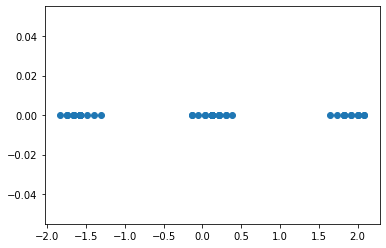

```python
# Implement Oja's rule here extending your previous implementation
# of the simple Hebb rule. Note that this question on Oja's rule
# uses a different dataset. So, don't forget to change the dataset
# after you have copied the code to this block.

from sklearn.decomposition import PCA

# load data from the text file
data = np.loadtxt('data_HL_simple.txt', usecols=range(5))
print(data[1:5,:])

# we need a vector of 5 parameters
w = np.random.normal(0, 0.5, 5)

print("initial weights")
print(w)

# learning rate; don't change the learning rate epsilon when you are working on questions 2 and 3, unless you really know what you are doing. You may want to make the learning rate dependent on the epoch number to converge to a stable solution.
epsilon = 0.01

num_iterations = 6

update = 0
# we can do a fixed number of iterations because the simple Hebb rule won't converge
for i in range(num_iterations):
    for x in data:

        # TODO: add your code here; note that "epsilon"
        # is defined above and it should be used here;
        # don't change its default value in this question.

        y = np.dot(x,w)
        delta_w = epsilon*(x*y-y*y*w)

        w = w+delta_w

        update = update + 1
        if update % 10 == 0:
            # print every 10th update
            print("\tCurrent input: " + str(x))
            # print the weights for every x to see how they are evolving
            print("New Weights:\n" + str(w))

# the final weights
print(w)


# do PCA and show the data in 1D
plt.figure(2)
pca = PCA(n_components=1)
# fit the model parameters
pca.fit(data)
print("all principal components:")
print(pca.components_)
# project the data to the new dimension
data_pca = pca.transform(data)
# a vector of zeros for the scatter plot
yaxis = np.zeros(data_pca.shape[0])
plt.scatter(data_pca[:,0], yaxis)
plt.show()
```

**(3-5):** Run your implementation of Oja's rule on `data_two_groups.txt`. Use the vector of parameters $w$ that you will obtain using Oja's rule to project the original five-dimensional data into 1 dimension defined by $w$. The image that you will obtain should be similar to the one produced by PCA in `sklearn` above. The images may be identical if you have run Oja's rule until convergence, but this is not guaranteed. This step will allow you to see very clearly how a low dimensional representation (and hence data compression) can be achieved using Hebbian learning/Oja's rule or PCA.

```
[[-0.20752314 -0.36773773  1.22059844  0.55048877  1.88427215]
 [-1.57125555  1.32390861 -1.47812951 -1.43172722 -3.19127369]
 [-0.82290562  2.27103446 -2.12484964 -2.12484964 -4.13049738]
 [ 0.97027764  0.91336865 -3.52387133 -3.22573866 -6.63143683]]
initial weights
[-0.98095832  0.68054794  0.08016077  0.47127818 -0.1442524 ]
	Current input: [-0.14225842  0.92044523 -1.62046158 -1.62046158 -3.44263005]
New Weights:
[-0.94896868  0.68547648  0.01825993  0.36478165 -0.24246409]
	Current input: [ 1.04787451 -0.18319438  0.8286063   2.55352384  3.10636035]
New Weights:
[-0.25900281  0.24311051 -0.40561017 -0.28733495 -0.86410382]
	Current input: [-0.64991566  0.56822123  4.02756301  4.02756301  8.35542888]
New Weights:
[ 0.06675827 -0.05688604 -0.40033737 -0.4000365  -0.83038056]
	Current input: [ 1.17858979 -0.62115521  2.18768608  2.18768608  4.23762284]
New Weights:
[-0.07015278  0.03317763 -0.39781101 -0.41984352 -0.81611201]
	Current input: [ 0.43291965 -1.92305982  2.43448814  2.44039988  5.1292251 ]
New Weights:
[-0.06397894  0.12108688 -0.41542329 -0.38823784 -0.82164615]
	Current input: [ 1.00493675 -0.45095789  1.27932744  1.27932744  2.74903112]
New Weights:
[-0.01068043  0.01093749 -0.406295   -0.41871964 -0.81746746]
	Current input: [ 0.9102205  -2.05750114 -2.51038077 -2.51038077 -4.85513938]
New Weights:
[ 0.08678227 -0.12743402 -0.41752216 -0.40939691 -0.80970383]
	Current input: [ 1.21952826 -1.10204926 -1.41856678 -3.20466734 -4.61156575]
New Weights:
[ 0.0877217  -0.07554782 -0.35574569 -0.46667177 -0.81021973]
	Current input: [0.31282946 0.26833798 2.86240436 2.86240436 5.55783425]
New Weights:
[-0.05950772 -0.04580192 -0.42563765 -0.39955128 -0.80922673]
	Current input: [ 0.2249605  -2.13872179 -1.74648565 -1.74648565 -3.80626361]
New Weights:
[-0.01013898 -0.06948741 -0.40159127 -0.41706502 -0.82141671]
	Current input: [-0.14225842  0.92044523 -1.62046158 -1.62046158 -3.44263005]
New Weights:
[-0.0998458   0.0304824  -0.41120146 -0.40271576 -0.82136604]
	Current input: [ 1.04787451 -0.18319438  0.8286063   2.55352384  3.10636035]
```

[output cut: 134 more lines]

```
	Current input: [ 0.9102205  -2.05750114 -2.51038077 -2.51038077 -4.85513938]
New Weights:
[ 0.08678228 -0.12743403 -0.41752216 -0.40939691 -0.80970383]
	Current input: [ 1.21952826 -1.10204926 -1.41856678 -3.20466734 -4.61156575]
New Weights:
[ 0.0877217  -0.07554782 -0.35574569 -0.46667177 -0.81021973]
	Current input: [0.31282946 0.26833798 2.86240436 2.86240436 5.55783425]
New Weights:
[-0.05950772 -0.04580192 -0.42563765 -0.39955128 -0.80922673]
	Current input: [ 0.2249605  -2.13872179 -1.74648565 -1.74648565 -3.80626361]
New Weights:
[-0.01013898 -0.06948741 -0.40159127 -0.41706502 -0.82141671]
[-0.01013898 -0.06948741 -0.40159127 -0.41706502 -0.82141671]
all principal components:
[[0.01640681 0.02155885 0.40640946 0.4106701  0.81574963]]
```

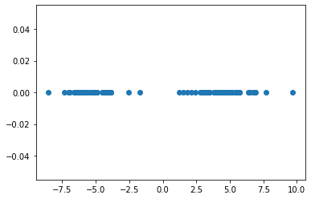

```python
# Implement Oja's rule here extending your previous implementation
# of the simple Hebb rule. Note that this question on Oja's rule
# uses a different dataset. So, don't forget to change the dataset
# after you have copied the code to this block.

import numpy as np

# load data from the text file
data = np.loadtxt('data_two_groups.txt', usecols=range(5))
print(data[1:5,:])

# we need a vector of 5 parameters
w = np.random.normal(0, 0.5, 5)

print("initial weights")
print(w)

# learning rate; don't change the learning rate epsilon when you are working on questions 2 and 3, unless you really know what you are doing. You may want to make the learning rate dependent on the epoch number to converge to a stable solution.
epsilon = 0.01

num_iterations = 6

update = 0
# we can do a fixed number of iterations because the simple Hebb rule won't converge
for i in range(num_iterations):
    for x in data:

        # TODO: add your code here; note that "epsilon"
        # is defined above and it should be used here;
        # don't change its default value in this question.

        y = np.dot(x,w)
        delta_w = epsilon*(x*y-y*y*w)

        w = w+delta_w

        update = update + 1
        if update % 10 == 0:
            # print every 10th update
            print("\tCurrent input: " + str(x))
            # print the weights for every x to see how they are evolving
            print("New Weights:\n" + str(w))

# the final weights
print(w)


# do PCA and show the data in 1D
plt.figure(2)
pca = PCA(n_components=1)
# fit the model parameters
pca.fit(data)
print("all principal components:")
print(pca.components_)
# project the data to the new dimension
data_pca = pca.transform(data)
# a vector of zeros for the scatter plot
yaxis = np.zeros(data_pca.shape[0])
plt.scatter(data_pca[:,0], yaxis)
plt.show()
```

**(1-2):** In the above code, identify Python variables that correspond to the symbol $y_j$ in our lecture notes. What is the range of $j$ in this example? How does the number of values of $y_j$ relate to the number of data examples?

```python
import math
import numpy as np
import matplotlib.pyplot as plt
import pandas as pd

from sklearn.datasets import load_iris
from sklearn.decomposition import PCA

# load the data from sklearn
iris = load_iris()

# X is np.ndarray and it contains four predictor attributes
X = iris.data
y = iris.target

# print descriptive statistics using pandas data frame
df_X = pd.DataFrame(X)
print(df_X.describe())
```

```
                0           1           2           3
count  150.000000  150.000000  150.000000  150.000000
mean     5.843333    3.057333    3.758000    1.199333
std      0.828066    0.435866    1.765298    0.762238
min      4.300000    2.000000    1.000000    0.100000
25%      5.100000    2.800000    1.600000    0.300000
50%      5.800000    3.000000    4.350000    1.300000
75%      6.400000    3.300000    5.100000    1.800000
max      7.900000    4.400000    6.900000    2.500000
```

```python
# the number of principal components
n_components = 2

pca = PCA(n_components=n_components)
```

```python
# We fit the model and then transform the data.

# Fit the model to the data; this is where PCA will do what Hebbian learning does to compute one principal component
pca.fit(X)

# print the principal components
print(pca.components_)

# we can now transform the data and project it to 2 dimensions.
X_pca = pca.transform(X)

print(X_pca[:5,:])
print(X[:5,:])
```

```
[[ 0.36138659 -0.08452251  0.85667061  0.3582892 ]
 [ 0.65658877  0.73016143 -0.17337266 -0.07548102]]
[[-2.68412563  0.31939725]
 [-2.71414169 -0.17700123]
 [-2.88899057 -0.14494943]
 [-2.74534286 -0.31829898]
 [-2.72871654  0.32675451]]
[[5.1 3.5 1.4 0.2]
 [4.9 3.  1.4 0.2]
 [4.7 3.2 1.3 0.2]
 [4.6 3.1 1.5 0.2]
 [5.  3.6 1.4 0.2]]
```

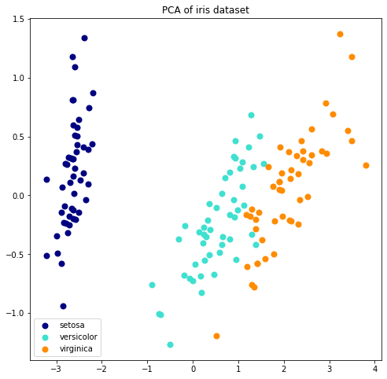

```python
colors = ['navy', 'turquoise', 'darkorange']
title = "PCA"

plt.figure(figsize=(8, 8))
for color, i, target_name in zip(colors, [0, 1, 2], iris.target_names):
    # note that y are targets defined above
    plt.scatter(X_pca[y == i, 0], X_pca[y == i, 1],
                    color=color, lw=2, label=target_name)

plt.title(title + " of iris dataset")
plt.legend(loc="best", shadow=False, scatterpoints=1)

plt.show()
```

```python
"""The variable y is an array that holds the class labels for each sample in the Iris dataset.
Range of j is from 0 to 149 (0 to n-1, where n is number of total examples here it is 150).
The class labels are integers representing different classes (0, 1, and 2) corresponding to the Iris species.
"""

n=len(y)
print("No of data examples: ",n)
print("j ranges from 0 to ",n-1)
```

```
No of data examples:  150
j ranges from 0 to  149
```

**(3-1)** Compute `data_rec`, which is the reconstruction of the original data from its compressed 1D representation that is stored in `data_pca`.

```
[[1.03073034 0.50488764]
 [0.73073034 0.35488764]
 [1.21073034 0.50488764]
 [1.46073034 1.55488764]
 [0.66073034 0.50488764]]
the parameters/axis
[[0.86285419 0.50545291]]
data_pca is the 1D representation of our data:
[[0.80989272]
 [1.29988067]
 [2.04631978]
 [0.82531087]]
```

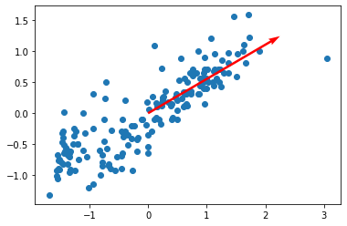

```python
from sklearn.datasets import load_wine
import pandas as pd
import matplotlib.pyplot as plt

wine = load_wine()
#dfwine = pd.DataFrame(wine.data, columns=wine.feature_names)
#print(dfwine.corr())

# we select 2 features that are correlated in this dataset
ind = [wine['feature_names'].index('flavanoids'), wine['feature_names'].index('total_phenols')]
data = wine.data[:,ind]
# we centre the data to make the code below simpler
data = data - np.mean(data, axis=0)
print(data[0:5,:])

# we will extract 1 component; note that our data is 2D
n_components = 1

pca = PCA(n_components=n_components)

# We fit the model and transform the data in one line.
data_pca = pca.fit_transform(data)
print("the parameters/axis")
print(pca.components_)
print("data_pca is the 1D representation of our data:")
print(data_pca[1:5])

# plot the data with the first PC
plt.scatter(data[:,0], data[:,1])
plt.quiver(pca.components_[0][0], pca.components_[0][1], color=['red'], scale=2)
plt.show()

# data is the original data, and data_pca is the low dimensional representation of the data
# your next step is to compute data_rec, which will be the reconstruction of the original data using data_pca
# we are interested in the errors between data and data_rec
```

```
Reconstructed data:
[[0.69881933 0.40936263]
 [1.12160749 0.65702847]
 [1.7656756  1.03431828]
 [0.71212294 0.41715578]]
```

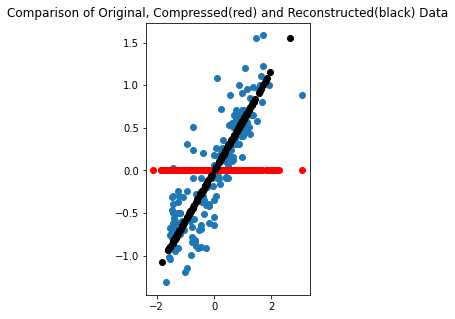

```python
data_rec = pca.inverse_transform(data_pca)

print("Reconstructed data:")
print(data_rec[1:5, :])

plt.figure(figsize=(10, 5))

plt.subplot(1, 3, 1)
plt.scatter(data[:, 0], data[:, 1])
plt.title('Comparison of Original, Compressed(red) and Reconstructed(black) Data')

plt.scatter(data_pca, np.zeros_like(data_pca), color='r')

plt.scatter(data_rec[:, 0], data_rec[:, 1], color='black')

plt.show()
```

(**Last question**)This question will require the students to engage with the scientific literature. The challenge is to compare the Delta Rule with the Perceptron learning algorithm. The comparison should highlight two differences of both methods. The differences can be related to both how these algorithms work and the properties of the learned models. A technical explanation is required, that is, every difference must be explained using technical terms. Cite the sources that will be used to answer this question. Use books or peer-reviewed scientific papers published in journals or conference-proceedings (blogs and websites are not in this category).

**Comparison**

The Delta Rule, also known as the Widrow-Hoff rule, is a learning technique that neural networks use to modify the weights of its connections. The objective is to minimize the discrepancy between the anticipated and anticipated outputs of the neural network through weight adjustments until the error goes to zero. updating the weights associated with the error's negative gradient. The gradient descent optimization principle underpins this rule.

A Perceptron learning algorithm is a binary classification method for a single-layer perceptron. The weights are modified based on the discrepancy between the true and predicted target outputs. If the anticipated output is correct, there is no update. However, if a misclassification happens, the error is multiplied by the product of the input and the learning rate to update the weights. The primary difference is evident in the weight updating procedure. The Delta Rule employs a gradient descent technique, adjusting weights in accordance with the gradient of the error surface, to produce smoother convergence. Conversely, because the Perceptron learning algorithm uses a simple update mechanism and only assumes the existence of misclassifications, it is less suitable for non-linearly separable data.

Neural networks can be trained for both linear and non-linear problems using the Delta Rule, which is more flexible in terms of convergence and linearity. Because it uses gradient descent, which allows it to converge for a wider variety of functions, it can navigate complex error surfaces. The Perceptron learning algorithm is specifically designed for linearly separable problems. Convergence is guaranteed if the data can be divided linearly. If not, it may not converge for problems that cannot. The Perceptron learning technique is limited to problems that can be separated linearly, while the Delta Rule is more flexible and can handle both linear and non-linear separability due to its gradient descent-based methodology.

**Sources:**

1. Rosenblatt, F. (1958). The Perceptron: A Probabilistic Model for Information Storage and Organization in the Brain. *Psychological Review*, 65(6), 386-408.
2. Widrow, B., & Hoff, M. E. (1960). Adaptive Switching Circuits. *IRE WESCON Convention Record*, 96-104.
3. Duda, R. O., Hart, P. E., & Stork, D. G. (2012). *Pattern Classification*. John Wiley & Sons.